# Are Presidents What They Say?

Ziwei Meng

2017-02-2

# Introduction

It is said that people are what they eat, but maybe not what they say. Even US presidents make promise never implemented, or exaggerate their achievements.  
However, we still believe there are something information, about the speeker himself, his party, or the historical environment behind him, could be retreived.  
In this article, we basically asked 3 questions,

How does Republican focus differently from Democratic,

How does words-choosing reflect national economic environment, and

How does presidents’ moods change at farewell compared to inauguration.

Crude answers are, Republicans call for jobs while Democrats call for money, a nominee’s speech is more practical then a president, while a newly-elected president is happier than a nominee.  
Now let me navigate you through the data, clarify assumptions, and see how we end up there.

# How does Republican focus differently from Democratic

## A baseline

To set up a baseline, I simply calculated the word frequency and see there are some popular words among all the presidents, like “American”, “people” and “nation”. Here we already smell the style of presidential speech.

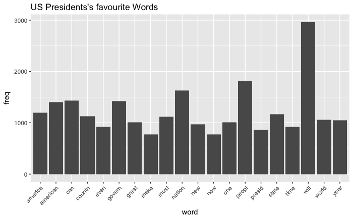

## With Trump

Since we focus on comparison between Republican and Democratic, a few speeches associated with Federalist or Whig are omitted. We group these documents into two corpus. Our basic assumotions are, if a word appears many times in a specific document, then it features that document, but if this word also appears many times in most documents, then it is more likely a general word, and hence we shrink it’s importance to that specific document. And then we simply use mean importance as the word’s weight to a group.

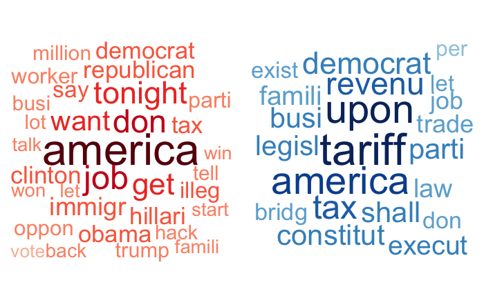

## Without Trump

Clearly presidents from both parties talk a lot about America, and we already see some differences between these two groups. Worker, immigrant and illegal in red, revenue, tariff and trade in blue. I just notice that there are some specific names in red, like Hillary, Obama and Trump, and somehow I suspect Trump contributes a lot in that. So I leave out Trump for the time being and see what happens.

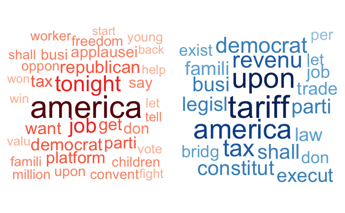

Boom! Those names go away with Trump, and some new words like children and freedom come in. You would have to admit that Trump has a significant influence on the word map for the whole party, his absence almost reshapes the landscape.

## A contrast.

To make the comparison even sharper, I literally calculated the difference between those words weights, and let’s see which words are drawn higher attention from which party.

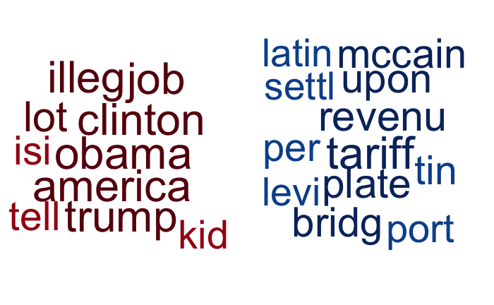

On last pair of pictures we see “job” appears on both sides, but here it becomes clear that Republicans address even more on jobs then Democrats, it is one of the deepest red word except for those names(again, Trump really dominates the impression of his party). On the other hand, revenue and tariff are two of the deepest blue words. If we are bold enough we would draw the conclusion that Republicans emphasize more on jobs while Democrats emphasize more on money.Let’s make a quick check.  
Presidents who mentioned tariff most are,

```
[1] "Al Smith"              "William J. Clinton"    "Ronald Reagan"
[4] "Harry S. Truman"       "Franklin D. Roosevelt"
```

4 of first 5 are Democrats, and Presidents who mentioned job most are,

```
[1] "Benjamin Harrison"     "William J. Clinton"    "Franklin D. Roosevelt"
[4] "Richard Nixon"         "Warren G. Harding"
```

3 of first 5 are Republicans.

# How does words-choosing reflect national economic environment

Now let’s introduce some other data to make things more interesting.  
I assume that presidents base their speeches on some realities, maybe they promise a lot about jobs in the nomination when unemployment is high, or brag more about jobs they have created at farewell when GDP growth does become higher. Or they just follow what they believe to be important and never take a look at the economy index the night before an address.  
It is mysterious how they knit realities into their speeches and at what situation. Hence I downloaded GDP growth percentage per quarter and unemployment per month data from [U.S. Bureau of Labor Statistics](https://www.bls.gov/), compare them to the word frequency of nearest following address.  
We focus on speeches after 1952 since from then reliable unemployment and GDP statistics become available.

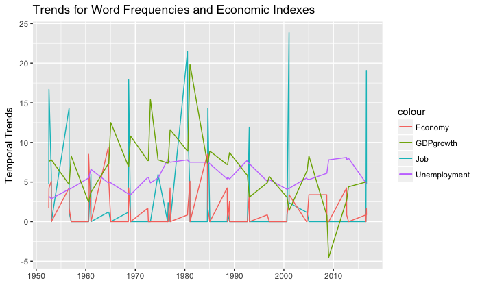

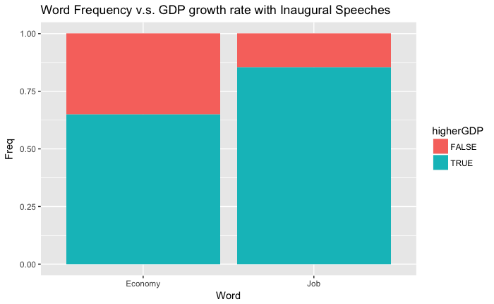

|  | unemployment | GDPgrowth |
| --- | --- | --- |
| job | 0.9212697 | 0.01969945 |
| economy | 0.3208697 | 0.17883908 |

# How does presidents’ moods change at farewell compared to inauguration

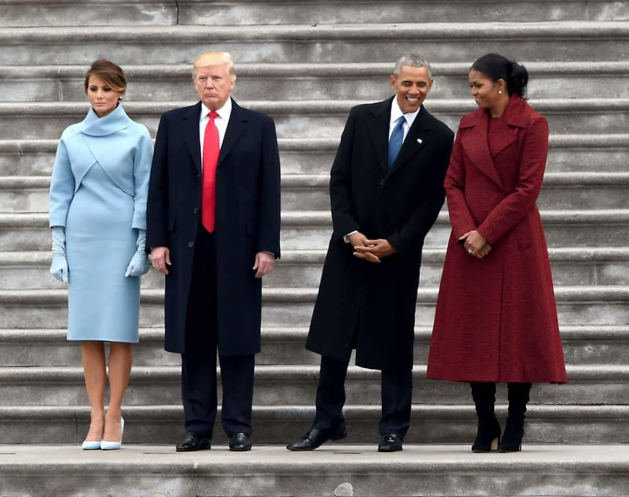

Well, I used mean positive sentiment level as a metric and compare different types of speeches. And actually I got very small p-values(see last table) that the difference among those groups is unlikely due to random sampling.

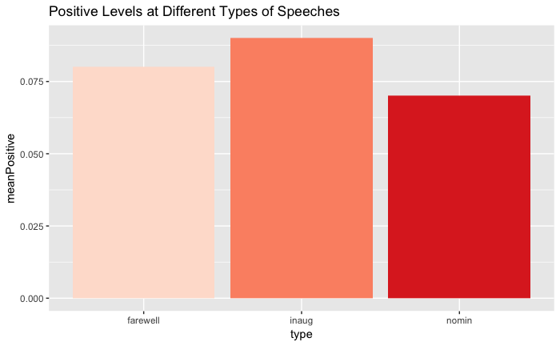

```
    Pairwise comparisons using t tests with pooled SD

data:  mood_type$positive and mood_type$type

      farewell inaug
inaug 5.4e-05  -
nomin 0.00064  < 2e-16

P value adjustment method: bonferroni
```

On the contrary of the picture above, it seems that a president is happiest at inaugural, then at farewell, least positive at nomination.  
It is actually quite understandable. Landing on your dream job is sweet, retirement after intensive career years might be a release, but an uncertain job offer with powerful competitors in future can be quite stressful.

# To be continued…

Here are some questions emerged through our analysis, for example,

Why only in inaugural speeches we find association between “job” frequency and GDP growth?

Can we use annual GDP/unemployment instead of quarterly? What would happen then?

Are there better metrics then mean of sentences to tag sentiment for each document?

Works are not done!Stay tuned.